# MBA em Gestão Estratégica em Banking - In Company Banrisul - UNISINOS

- Estatística e econometria para gestão de risco de crédito e da formação da carteira de investimentos
- Ano/Semestre: 2020/1
- Professor: Prof. Msc. Davi Souza Simon

### Status

- Revisão de conceitos básicos - ok!
- Estatística Descritiva - ok!
- Teste de Hipóteses - ok!
- Regressão Linear -
- Regressão Logística -
- R e RStudio - ok!

### Regressão Linear

Curiosidade matemática, para quem acha interessante. https://www.khanacademy.org/math/precalculus/precalc-matrices/solving-equations-with-inverse-matrices/v/matrix-equations-systems

### Regressão Linear

O gráfico de dispersão representado abaixo mostra a relação entre a taxa de conclusão do ensino médio (high school) em todos os 51 estados americanos [eixo c] e o percentual de pessoas vivendo abaixo da linha de probreza (renda abaixo de $23,050 para uma família de 4 pessoas em 2012) [eixo y].

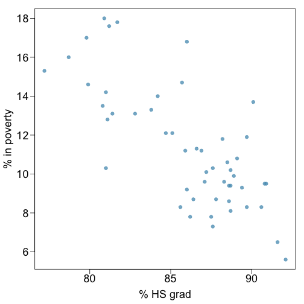

### Regressão Linear

Se tentarmos descrever a relação entre a taxa de conclusão do ensino médio (high school) em todos os 51 estados americanos e o percentual de pessoas vivendo abaixo da linha de probreza, assumindo uma relação linear, chegamos a reta em vermelho, por meio de uma regressão linear (método dos mínimos quadrados ordinários)

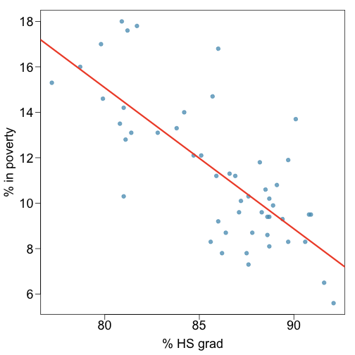

### Regressão Linear

- O coeficiente de correlação é uma medida estatística que descreve a força da associação linear entre duas variáveis.
- Ele assume valores entre -1 e 1.
- Um valor de 0 indica não haver associação linear

### Regressão Linear

Nos gráficos abaixo, qual a força da associação linear entre as variáveis do eixo x e do eixo y?

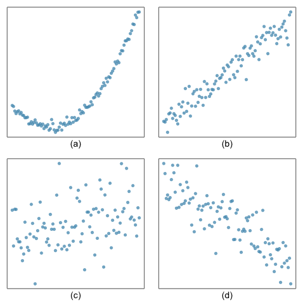

### Regressão Linear

```r
cor(yNonLin,x)
```

```
[1] 0.8338696
```

```r
cor(yPosLinStrong,x)
```

```
[1] 0.9659542
```

```r
cor(yPosLinWeak,x)
```

```
[1] 0.3567084
```

```r
cor(yNegLinWeak,x)
```

```
[1] -0.8521212
```

Volte à página anterior, e veja se as correlações acima correspondem à sua análise visual. Depois disso, prossiga para o slide seguinte.

### Regressão Linear

Uma análise dos dados da Natura. Começamos importando os dados e fazendo alguns ajustes.

```r
dados <- read_excel("NaturaTrim.xlsx",sheet=1, col_names = TRUE, col_types = NULL, na = "-", skip = 2)
colnames(dados) <- c("Data","Div_p_acao","Valor_Mercado","Ativo_Total","Patrim_Liq","Preço_Lucro"
                     ,"Retorno","Cotação","EBIT","Lucro_Liq","CaixaEq","Apl_Fin","Divida_Bruta",
                     "Liq_Bolsa","Negociabilidade","Beta2anos","Beta3anos","Debt_to_Equity",
                     "IDIV","IBOV","ISEE")

#transformamos os preços do índice IBOVESPA em retornos logarítmicos
d <- data.frame(exp(diff(log(dados$IBOV))) - 1)

#transformamos os preços da Natura em retornos logarítmicos
d$Natura <- exp(diff(log(dados$Cotação)))-1
colnames(d) <- c("IBOV","Natura")
```

### Regressão Linear

Analisando a relação entre os retornos do IBOVESPA e a Natura

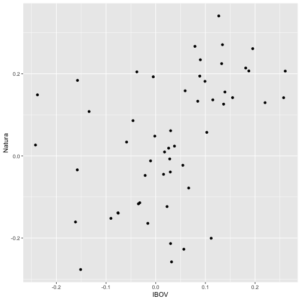

```r
ggplot(data=d) + geom_point(aes(x=IBOV, y=Natura))
```

### Regressão Linear

```r
d <- d[complete.cases(d),]
cor(d$IBOV,d$Natura)
```

```
[1] 0.4424937
```

### Regressão Linear

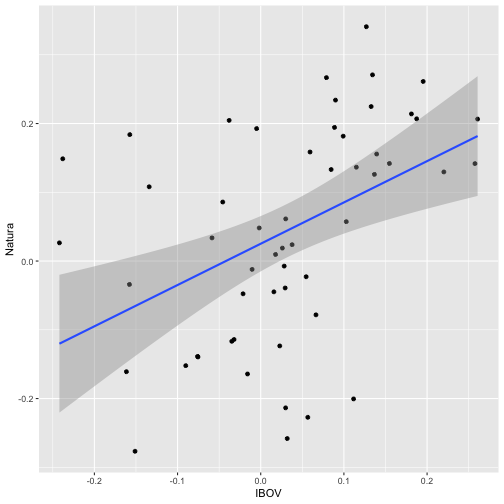

```r
ggplot(data=d) + geom_point(aes(x=IBOV, y=Natura)) + geom_smooth(aes(x=IBOV, y=Natura), method="lm")
```

### Regressão Linear

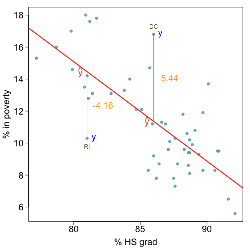

### Fórmulas práticas (OLS)

\[ { \hat{y} = \beta_0 + \beta_1 x } \]

A inclinação da reta de regressão linear, que é o coeficiente angular da reta, pode ser calculada da seguinte forma:

\[ b_1 = \frac{s_y}{s_x} R \]

Pode ser calculada no excel com a função “Inclinação”.

Para cada variação de uma unidade de nossa variável explicativa (x), esperamos uma variação de \( \beta_1 \) unidades de nossa variável dependente (y) .

### Fórmulas práticas (OLS)

O intercepto é o coeficiente linear da reta, indicando em que nível ela cruza o eixo \( y \).

\[ b_0 = \bar{y} - b_1 \bar{x} \]

Pode ser calculada no excel com a função “Intercepção”

### Derivação do Estimador de MQO (OLS)

- Y é potencialmente função de uma matriz X composta por diversas variáveis explicativas
- Estimamos os coeficientes que melhor explicam a relação entre Y e a matrix X, minimizando o erro ao quadrado
- Derivação: https://economictheoryblog.com/2015/02/19/ols_estimator/

### Estimando os Betas com matrizes

```r
## Criando uma base de dados artificial
set.seed(12345)

#  Adubo para soja por Hectare
adubo <- rnorm(300,40,sd = 10)
require(tseries)
jarque.bera.test(adubo)
```

```
    Jarque Bera Test

data:  adubo
X-squared = 0.94628, df = 2, p-value = 0.623
```

### Estimando os Betas com matrizes

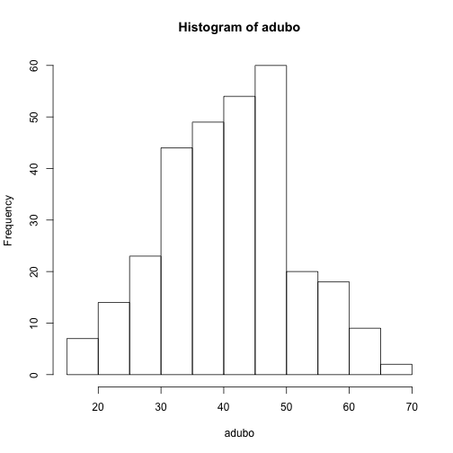

```r
hist(adubo)
```

### Estimando os Betas com matrizes

```r
#  produtividade simulada
produtividade <- adubo*1.2+rnorm(300,0,sd = 10)

#  Incluindo ambos em um data frame
df <- data.frame(produtividade,adubo)
```

### Estimando os Betas com matrizes

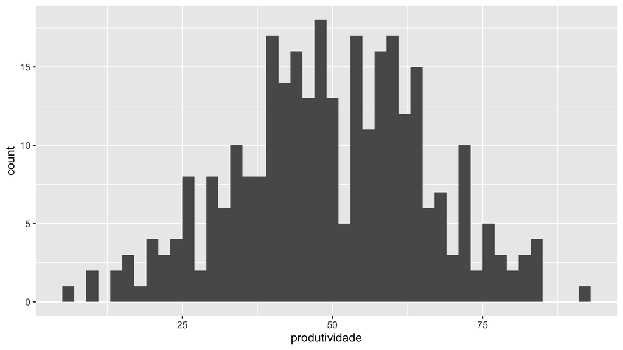

```r
g <- ggplot(df, aes(produtividade))
g + geom_histogram(binwidth = 2)
```

### Estimando os Betas com matrizes

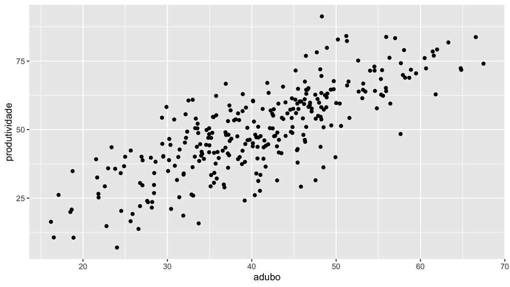

```r
h <- ggplot(df, aes(adubo, produtividade))
h <- h + geom_point()
h
```

### Estimando os Betas com matrizes

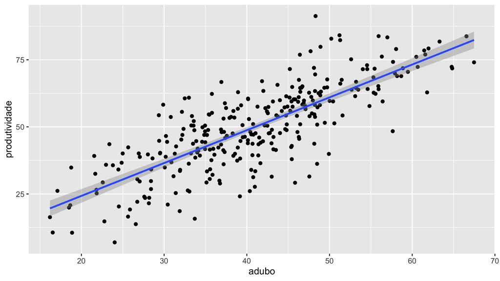

```r
h <- ggplot(df, aes(adubo, produtividade))
h <- h + geom_point()
h <- h + geom_smooth(aes(adubo, produtividade),method="lm")
h
```

### Estimando os Betas com matrizes

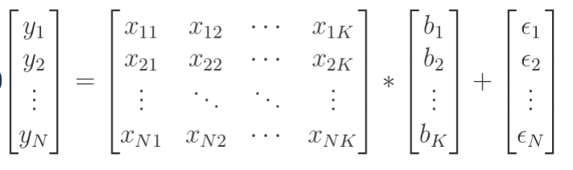

### Estimando os Betas com matrizes

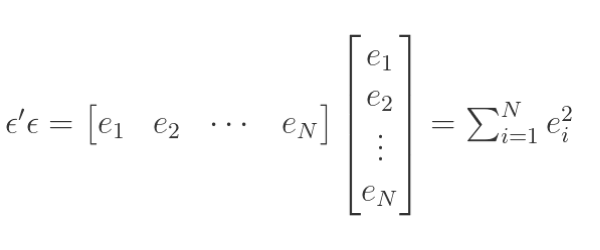

### Estimando os Betas com matrizes

(X'X)<sup>-1</sup> * (X'Y)

```r
#  Definição das Matrizes X e Y
X <- as.matrix(cbind(1,df$adubo))
Y <- as.matrix(df$produtividade)
```

### Estimando os Betas com matrizes

(X'X)<sup>-1</sup> * (X'Y)

```r
#Estimando coeficientes beta
beta <- solve(t(X)%*%X)%*%(t(X)%*%Y)
beta
```

```
          [,1]
[1,] -0.179566
[2,]  1.223367
```

### Estimando os Betas com matrizes

(X'X)<sup>-1</sup> * (X'Y)

```r
#Y Previsto e Resíduos

df$Yhat <- as.matrix(beta[1]+beta[2]*X[,2])
df$res <- as.matrix(Y-beta[1]-beta[2]*X[,2])
res <- df$res # vai ser útil depois
```

- Inspecionar o objeto “df”

### Estimando os Betas com matrizes

```r
## número de observações e parâmetros
n <- nrow(df)
k <- ncol(X)
```

### Estimando os Betas com matrizes

```r
## Matriz de Variância - Covariância (VCV)
#  VCV = (1/(n-k))res'res(X'X)^(-1)
VCV <- 1/(n-k) * as.numeric(t(res)%*%res) * solve(t(X)%*%X)

## calculate standard errors (se) of coefficients
se <- sqrt(diag(VCV))

## calculate the p-values
p_value <- rbind(2*pt(abs(beta[1]/se[1]), df=n-k,
                      lower.tail= FALSE),
                 2*pt(abs(beta[2]/se[2]), df=n-k,
                      lower.tail= FALSE))
```

### Estimando os Betas com matrizes

```r
## Combinando o resultado
output <- as.data.frame(cbind(c("(Intercept)","adubo"),
                                beta,se,p_value))
names(output) <- c("Coefficients:","Estimate",
                   "Std. Error","Pr(>|t|)")
```

### Comparando

```r
output
```

```
  Coefficients:           Estimate        Std. Error             Pr(>|t|)
1   (Intercept) -0.179566046647324  2.34679841560857     0.93906046538104
2         adubo   1.22336734912702 0.055770231893712 3.73518661292954e-64
```

### Comparando

```r
modelo1 <- lm(produtividade~adubo, data=df)
summary(modelo1)
```

```
Call:
lm(formula = produtividade ~ adubo, data = df)

Residuals:
    Min      1Q  Median      3Q     Max
-26.710  -5.856   0.250   6.222  32.358

Coefficients:
            Estimate Std. Error t value Pr(>|t|)
(Intercept) -0.17957    2.34680  -0.077    0.939
adubo        1.22337    0.05577  21.936   <2e-16 ***
---
Signif. codes:  0 '***' 0.001 '**' 0.01 '*' 0.05 '.' 0.1 ' ' 1

Residual standard error: 9.894 on 298 degrees of freedom
Multiple R-squared:  0.6175,    Adjusted R-squared:  0.6163
F-statistic: 481.2 on 1 and 298 DF,  p-value: < 2.2e-16
```

### Em resumo

- R não usa inversão de matrizes, pois o procedimento é muito trabalhoso e ineficiente.
- R usa QR decomposition, mais eficiente e segura para multicolinearidade
- https://en.wikipedia.org/wiki/QR_decomposition
- https://bookdown.org/rdpeng/advstatcomp/textbooks-vs-computers.html

### Regressão múltipla

- Um fenômeno Y pode ser uma função de diversas variáveis explicativas
- Regressão múltipla permite que avaliemos efeitos *ceteris paribus*
- Software estatístico

### Exemplo Natura

```r
dados$ret_mercado <- "NA"
dados$ret_mercado[2:56] <- exp(diff(log(dados$IBOV))) - 1
dados$ret_mercado <- as.numeric(dados$ret_mercado)
dados$ret_natura <- "NA"
dados$ret_natura[2:56] <- exp(diff(log(dados$Cotação))) - 1
dados$ret_natura <- as.numeric(dados$ret_natura)
```

### Exemplo Natura

```r
modelo1 <- lm(ret_natura ~ ret_mercado, data=dados)
summary(modelo1)
```

```
Call:
lm(formula = ret_natura ~ ret_mercado, data = dados)

Residuals:
     Min       1Q   Median       3Q      Max
-0.30248 -0.08733  0.01847  0.09757  0.26655

Coefficients:
            Estimate Std. Error t value Pr(>|t|)
(Intercept)  0.02519    0.02005   1.256 0.214567
ret_mercado  0.60065    0.16881   3.558 0.000807 ***
---
Signif. codes:  0 '***' 0.001 '**' 0.01 '*' 0.05 '.' 0.1 ' ' 1

Residual standard error: 0.1423 on 52 degrees of freedom
  (2 observations deleted due to missingness)
Multiple R-squared:  0.1958,    Adjusted R-squared:  0.1803
F-statistic: 12.66 on 1 and 52 DF,  p-value: 0.0008071
```

### Exemplo Natura

- A qualidade do ajuste de um modelo linear é dada pelo coeficiente \( R^2 \).
- \( R^2 \) é o quadrado do coeficiente de correlação.
- Ele nos diz qual o percentual da variação de Y é explicado pelo modelo (em função de variações de X)
- O restante da variabilidade é explicada por variáveis que não estão incluídas no modelo, ou por aleatoriedade dos dados.

### Exemplo Natura

```r
modelo2 <- lm(ret_natura ~ log(Ativo_Total) + ret_mercado, data=dados)
summary(modelo2)
```

```
Call:
lm(formula = ret_natura ~ log(Ativo_Total) + ret_mercado, data = dados)

Residuals:
     Min       1Q   Median       3Q      Max
-0.31327 -0.09318  0.01299  0.08570  0.24960

Coefficients:
                 Estimate Std. Error t value Pr(>|t|)
(Intercept)       0.69185    0.42159   1.641  0.10719
log(Ativo_Total) -0.04434    0.02801  -1.583  0.11978
ret_mercado       0.52130    0.17604   2.961  0.00471 **
---
Signif. codes:  0 '***' 0.001 '**' 0.01 '*' 0.05 '.' 0.1 ' ' 1

Residual standard error: 0.1424 on 49 degrees of freedom
  (4 observations deleted due to missingness)
Multiple R-squared:  0.2226,    Adjusted R-squared:  0.1909
F-statistic: 7.015 on 2 and 49 DF,  p-value: 0.002093
```

### Exemplo Natura

```r
modelo3 <- lm(ret_natura ~ log(Ativo_Total) + ret_mercado, data=dados)
summary(modelo2)
```

```
Call:
lm(formula = ret_natura ~ log(Ativo_Total) + ret_mercado, data = dados)

Residuals:
     Min       1Q   Median       3Q      Max
-0.31327 -0.09318  0.01299  0.08570  0.24960

Coefficients:
                 Estimate Std. Error t value Pr(>|t|)
(Intercept)       0.69185    0.42159   1.641  0.10719
log(Ativo_Total) -0.04434    0.02801  -1.583  0.11978
ret_mercado       0.52130    0.17604   2.961  0.00471 **
---
Signif. codes:  0 '***' 0.001 '**' 0.01 '*' 0.05 '.' 0.1 ' ' 1

Residual standard error: 0.1424 on 49 degrees of freedom
  (4 observations deleted due to missingness)
Multiple R-squared:  0.2226,    Adjusted R-squared:  0.1909
F-statistic: 7.015 on 2 and 49 DF,  p-value: 0.002093
```

### Exemplo Natura

```r
modelo4 <- lm(ret_natura ~ log(Ativo_Total) + ret_mercado + Negociabilidade + Debt_to_Equity + Div_p_acao, data=dados)
summary(modelo4)
```

```
Call:
lm(formula = ret_natura ~ log(Ativo_Total) + ret_mercado + Negociabilidade +
    Debt_to_Equity + Div_p_acao, data = dados)

Residuals:
      Min        1Q    Median        3Q       Max
-0.269352 -0.079803  0.008627  0.114338  0.268635

Coefficients:
                   Estimate Std. Error t value Pr(>|t|)
(Intercept)      -0.5246050  0.9625285  -0.545   0.5885
log(Ativo_Total)  0.0489735  0.0682157   0.718   0.4766
ret_mercado       0.5368905  0.1762143   3.047   0.0039 **
Negociabilidade  -0.1670017  0.0977889  -1.708   0.0947 .
Debt_to_Equity   -0.0003931  0.0002648  -1.485   0.1448
Div_p_acao        0.0001268  0.0404267   0.003   0.9975
---
Signif. codes:  0 '***' 0.001 '**' 0.01 '*' 0.05 '.' 0.1 ' ' 1

Residual standard error: 0.1405 on 44 degrees of freedom
  (6 observations deleted due to missingness)
Multiple R-squared:  0.2536,    Adjusted R-squared:  0.1688
F-statistic:  2.99 on 5 and 44 DF,  p-value: 0.0208
```

### Condições e testes

- As variáveis que compõem a matriz X tem que ser estritamente exógenas. Não dependem de Y. Quando se espera que não seja possível, necessário utilizar métodos mais avançados (IV Regression, GMM, etc.)
- Relação Linear

### Condições e testes

```r
install.packages("lmtest", repos = "http://cran.us.r-project.org")
library(lmtest)
install.packages("car", repos = "http://cran.us.r-project.org")
library(car)
install.packages("tseries", repos = "http://cran.us.r-project.org")
library(tseries)
```

### Multicolinearidade

(X'X)<sup>-1</sup> * (X'Y) demanda que seja possível inverter X'X. Assim, a matriz não pode ter duas colunas que sejam combinação linear, o que resultaria em um problema de multicolinearidade.

Testamos para ver se esse é um problema de duas formas:

- Matriz de Correlação - Temos que cuidar com variáveis com mais do que 70% de correlação
- Fator de Inflação de Variância - Temos que cuidar com variáveis com VIF maior do que dez

### Multicolinearidade

```r
vif(modelo4)
```

```
log(Ativo_Total)      ret_mercado  Negociabilidade   Debt_to_Equity
        5.626713         1.056634         1.190041         5.504783
      Div_p_acao
        1.213182
```

### Multicolinearidade

```r
variaveis <- c("ret_natura", "Ativo_Total", "ret_mercado", "Negociabilidade", "Debt_to_Equity")
D_Corr <- dados[,which(colnames(dados) %in% variaveis)]
cor(D_Corr)
```

```
                Ativo_Total Negociabilidade Debt_to_Equity ret_mercado
Ativo_Total               1              NA             NA          NA
Negociabilidade          NA               1             NA          NA
Debt_to_Equity           NA              NA              1          NA
ret_mercado              NA              NA             NA           1
ret_natura               NA              NA             NA          NA
                ret_natura
Ativo_Total             NA
Negociabilidade         NA
Debt_to_Equity          NA
ret_mercado             NA
ret_natura               1
```

### Correlação de Variáveis

```r
D_Corr <- D_Corr[complete.cases(D_Corr),]
lapply(D_Corr, class)
```

```
$Ativo_Total
[1] "numeric"

$Negociabilidade
[1] "numeric"

$Debt_to_Equity
[1] "numeric"

$ret_mercado
[1] "numeric"

$ret_natura
[1] "numeric"
```

### Correlação de Variáveis

```r
cor(D_Corr)
```

```
                Ativo_Total Negociabilidade Debt_to_Equity ret_mercado
Ativo_Total       1.0000000     -0.14673498      0.9565768 -0.17458003
Negociabilidade  -0.1467350      1.00000000     -0.2097584 -0.01925399
Debt_to_Equity    0.9565768     -0.20975841      1.0000000 -0.12806185
ret_mercado      -0.1745800     -0.01925399     -0.1280619  1.00000000
ret_natura       -0.2760327     -0.21624075     -0.2644993  0.42758537
                ret_natura
Ativo_Total     -0.2760327
Negociabilidade -0.2162407
Debt_to_Equity  -0.2644993
ret_mercado      0.4275854
ret_natura       1.0000000
```

### Correlação de Variáveis - Melhorando Apresentação

```r
install.packages("corrplot", repos = "http://cran.us.r-project.org")
library(corrplot)
```

### Correlação de Variáveis - Melhorando Apresentação

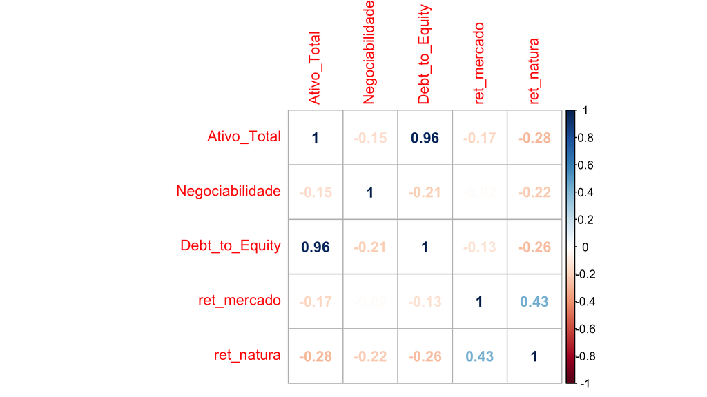

```r
      par(mfrow=c(1,1))
      corrplot(cor(D_Corr), method = "number") #plot matrix
```

### Correlação de Variáveis - Melhorando Apresentação

[figure not shown]

```r
      par(mfrow=c(1,1))
      corrplot(cor(D_Corr), method = "shade") #plot matrix
```

### Correlação de Variáveis - Melhorando Apresentação

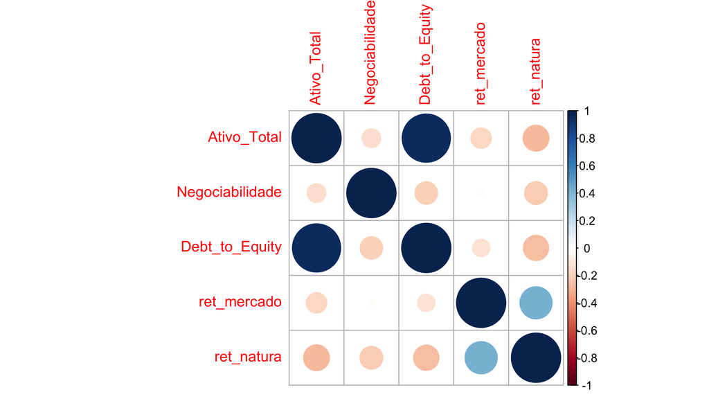

```r
      par(mfrow=c(1,1))
      corrplot(cor(D_Corr), method = "circle") #plot matrix
```

### Correlação de Variáveis - Melhorando Apresentação

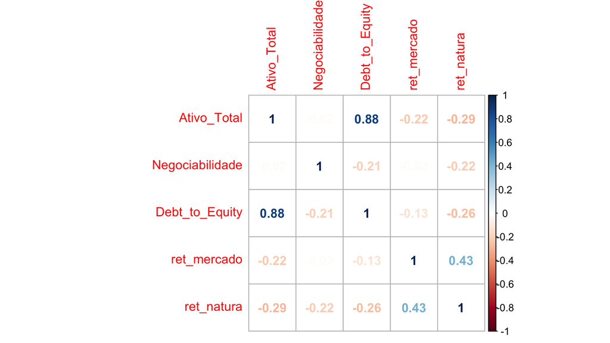

```r
  D_Corr$Ativo_Total <- log(D_Corr$Ativo_Total)
    par(mfrow=c(1,1))
      corrplot(cor(D_Corr), method = "number") #plot matrix
```

### Heterocedasticidade

- Erro esperado em função de X = 0
- Erros independentes , com valor esperado = zero e variância constante

```r
bptest(modelo4)
```

```
    studentized Breusch-Pagan test

data:  modelo4
BP = 6.7813, df = 5, p-value = 0.2374
```

### Normalidade dos resíduos

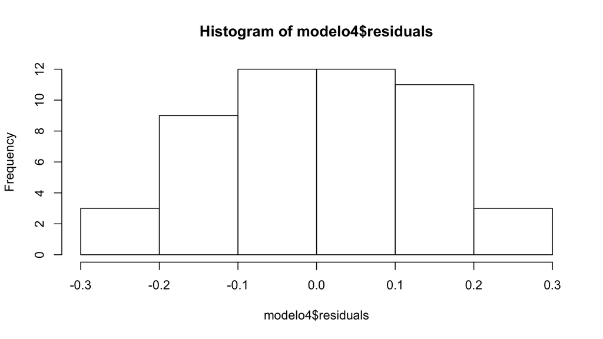

```r
hist(modelo4$residuals)
```

### Normalidade dos resíduos

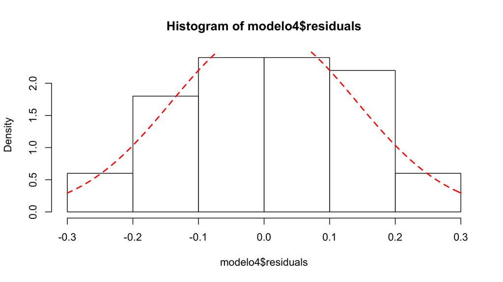

```r
hist(modelo4$residuals, freq=FALSE)
x<-seq(-1,+1,by=0.01)
curve(dnorm(x, mean=mean(modelo1$residuals), sd = sd(modelo1$residuals)), add=TRUE, col="red",lty=2,lwd=2)
```

### Normalidade dos Resíduos

Normalidade dos resíduos

```r
jarque.bera.test(modelo4$residuals)
```

```
    Jarque Bera Test

data:  modelo4$residuals
X-squared = 0.78765, df = 2, p-value = 0.6745
```

### Gráficos de Diagnóstico

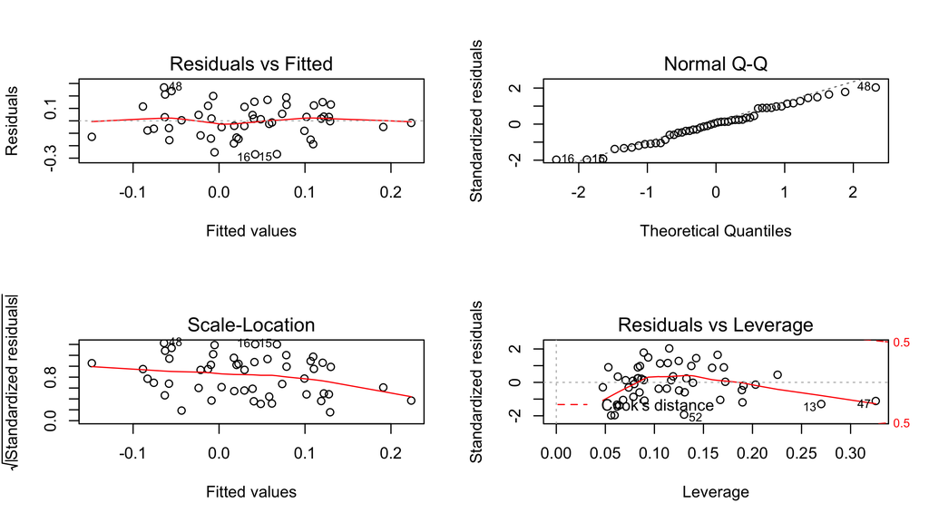

```r
par(mfrow=c(2,2))
plot(modelo4)
```

### Gráficos melhores

```r
install.packages("lindia", repos = "http://cran.us.r-project.org")
require(lindia)
```

### Gráficos melhores

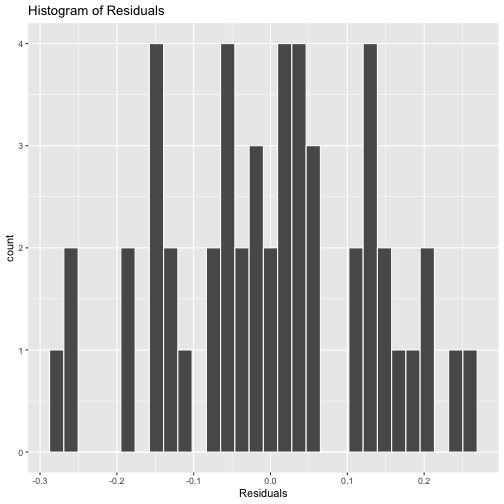

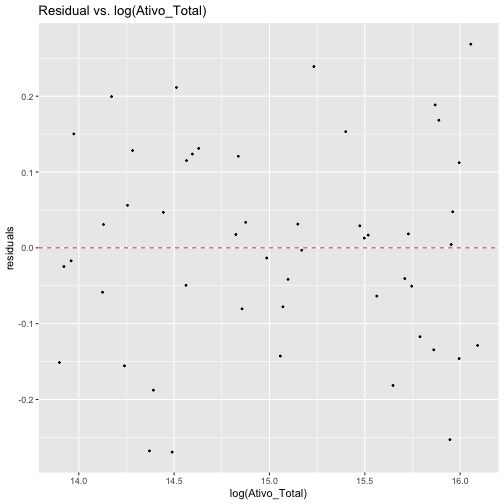

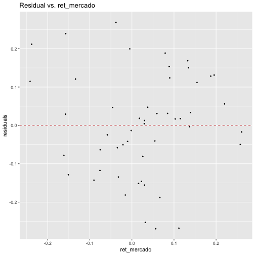

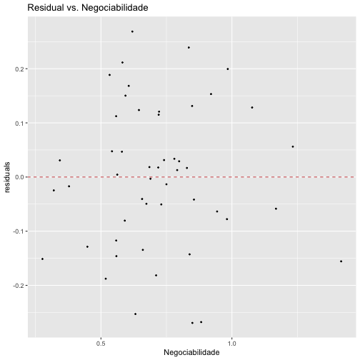

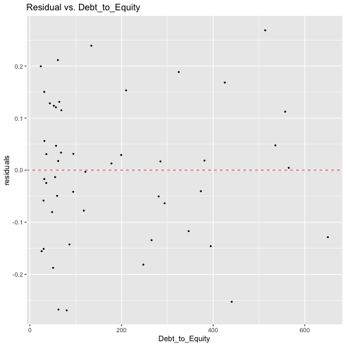

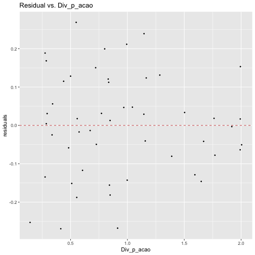

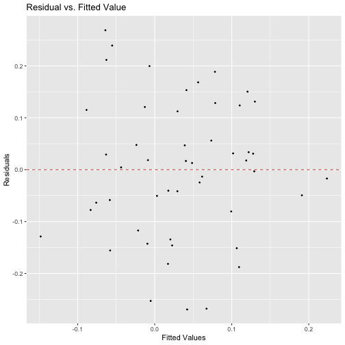

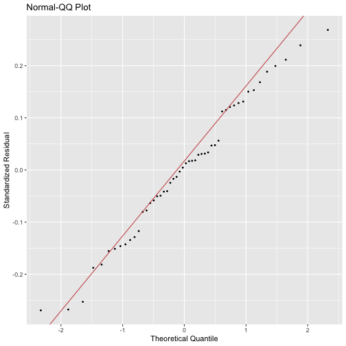

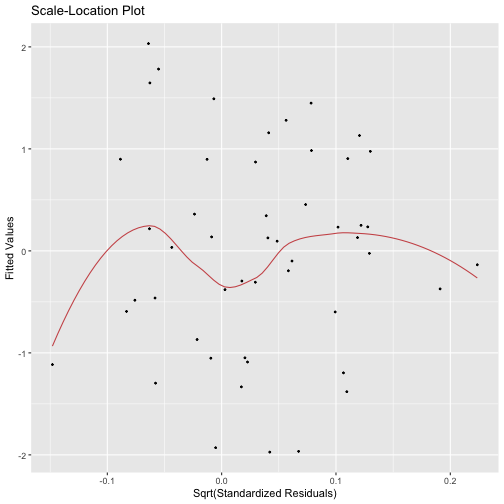

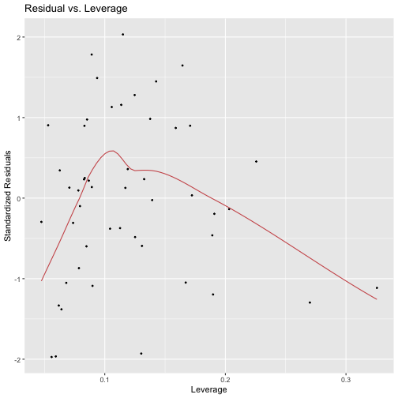

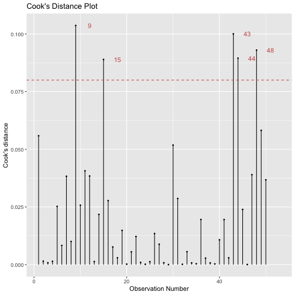

```r
gg_diagnose(modelo4, max.per.page = 1)
```